# Reproducible Research Project

Assessment Launch and AI Guidance

Philip Leftwich

University of East Anglia

2026-03-18

# Before We Start

## One Question

You have read the assessment brief.

**What is the one thing you are most uncertain about?**

Take 60 seconds. Write it down.

We will come back to these at the end.

# What This Assessment Is Actually Doing

## The Design Logic

This assessment has an unusual structure. It is worth understanding why.

- Most coursework lets you analyse data and write up at the same time
- This makes it very difficult to distinguish **good decisions** from **decisions that produced a tidy result**
- Pre-registering your analysis plan before seeing the data separates these two things

**The result is an assessment where genuine understanding is worth more than a polished document**

## The Three Components

| Component | Weight | What it establishes |
| --- | --- | --- |
| Preregistration | 25% | That you thought carefully before seeing the data |
| Analysis report and repository | 25% | That you completed a genuine analysis |
| Viva | 50% | That you understood what you did |

**The written components exist primarily as material for the viva**

A polished preregistration that you cannot discuss is worth very little. A rougher one that reflects genuine thinking is worth considerably more.

## The Preregistration Is Not a Contract

**Deviation from your preregistered plan is expected and is not penalised**

- Real data rarely behaves exactly as anticipated
- Cleaning decisions, unexpected distributions, variables that do not work as planned — these are normal
- What is required is that deviation is **explicitly flagged** in your report with a brief explanation

> The preregistration makes your thinking visible before the data does. The viva asks you to account for the gap between the two.

**Warning**

Unexplained deviation — where your analysis differs from the preregistration without acknowledgement — will be penalised.

# AI Tools — Where They Help and Where They Hurt

## Let’s Name the Tools

You are using these. We know you are using them. This session will tell you where they help and where they will cause you problems.

- **Research Rabbit, Connected Papers** — literature mapping
- **Consensus** — AI-assisted literature search
- **ChatGPT, Claude** — writing assistance, concept explanation
- **GitHub Copilot, ChatGPT** — code generation and debugging

The assessment does not have a blanket prohibition on AI tools.

It has a **boundary defined by what the viva will expose.**

## ✅ Fully Permitted: AI for Coding

Using AI tools to write, debug, and improve your R code in the analysis report is **explicitly permitted**.

- This reflects how quantitative researchers actually work
- Copilot, ChatGPT, and similar tools are legitimate coding assistants
- Getting help fixing an error, writing a ggplot, or restructuring a pipeline is fine

**The only requirement is that you understand what the code is doing well enough to explain it in the viva**

The viva question will not be “did you write this?” — it will be “walk me through what this code does and why you structured it this way”

## ✅ Permitted With Documentation: AI Literature Tools

Research Rabbit, Connected Papers, and Consensus are useful for **finding** papers.

- Use them to map the literature efficiently
- Use them to identify papers that cite your anchor paper
- Use them to check whether a topic has been studied quantitatively

**The requirement: document your search method transparently**

Record which tools you used and what you found. The Blackboard test asks for this explicitly.

## ⚠️ Where AI Assistance Actively Hurts You

**The DAG**

Your DAG must use the actual variable headers from your dataset. Every directed path must reflect your causal reasoning from the literature.

The viva will ask: *why did you include this confounder and not that one?*

> If an AI drew your DAG, you will not have an answer.

**Hypotheses and model specification**

These require reasoning about your specific question, your specific variables, and what your DAG implies about adjustment.

The viva will ask: *what does your DAG tell you about which variables need to be in your model?*

> If AI generated this, you will not be able to explain the connection.

## ✋ Think-Pair-Share (2 minutes)

**With the person next to you:**

If you used ChatGPT to write your model specification, what viva question would expose that?

*Be prepared to share one answer with the room.*

## The AI Boundary — Summary

| Activity | Status |
| --- | --- |
| AI coding assistance in the analysis report | ✅ Permitted |
| AI literature tools to identify papers | ✅ Permitted with documentation |
| AI to generate the DAG, hypotheses, or model specification | ⚠️ Will be exposed in viva |
| AI to generate effect size extraction or scale judgements | ⚠️ Requires reading the papers |
| Discussing your approach with other students | ✅ Permitted |
| Sharing your dataset or code with other students | ❌ Not permitted |

# The Preregistration Blackboard Test

## Six Sections — What Matters in Each

The Blackboard test has six sections. Submitting it releases your dataset automatically.

**Important**

You have one attempt. Draft your responses offline before entering them into Blackboard. The test has no time limit but once submitted it is locked.

## Section 1: Research Question

**Four components, one sentence each**

- The biological system or population
- The treatment, condition, or exposure
- The response variable — **be specific about units**
- The comparison you are making

This is the foundation everything else builds on. A vague research question produces a vague preregistration and a difficult viva.

## Section 2: Literature Search Documentation

**Document what you actually did — not what looks systematic in retrospect**

- Record every tool you used: Google Scholar, Research Rabbit, Connected Papers, Consensus
- Record any search strings exactly as entered
- Record the number of results before filtering
- For each included paper: one phrase on why included
- For each excluded paper: one phrase on why excluded

The search log is a record of a prospective process, not a post-hoc narrative. The viva will ask about specific exclusion decisions.

## Section 3: Effect Size Extraction

**Four items per paper — this requires reading the methods and results sections**

| Item | What to record |
| --- | --- |
| Sample size | Total and per group where relevant |
| Key result | Number with units — state what type of effect it is |
| Variability | SD, SE, or CI — or write “not reported” |
| Scale judgement | One sentence justifying your assessment |

A rough guide for the scale judgement: fewer than 30 observations per group and p just below 0.05 should be treated with caution — recall the winner’s curse from the power analysis lecture.

## Section 4: The DAG

**Two parts: paste your ggdag code, then annotate it**

- Your code must be **runnable** — your marker will run it
- Variable names must match the **dataset headers you have been given** — not generic placeholders
- The directed paths in the code must match the annotation

**The annotation asks five things:**

Exposure variable — outcome variable — confounders with justification — total or direct effect — variables you will adjust for

**Warning**

A DAG using generic variable names like `X`, `Y`, and `Z` rather than your actual dataset variables suggests the DAG was drawn without reference to the data structure. This will be noted.

## Section 5: Hypothesis Registration

**Directional where the literature supports direction**

- Between one and three hypotheses
- Each must state the predicted relationship, the direction, and the justification from the literature
- If you cannot justify a direction, register a non-directional hypothesis and explain why

**The format:**

*Based on [Author, Year], who found [specific result], I predict that [exposure] will [direction] [outcome] compared to [comparison group].*

## Section 6: Model Specification

**A paragraph, not a list — start from your DAG**

- What is your response variable and what type of data is it?
- What does your DAG tell you about which variables need to be in your model?
- What model will you fit and why does that follow from your response variable and causal reasoning?
- If you anticipate more than one model, what is the relationship between them?

Four to six sentences. Reads as a coherent plan. Connects the DAG to the model.

# The Analysis Report and Repository

## After the Dataset Is Released

You have the data. You have a preregistered plan. Now you analyse.

- Import, clean, and analyse the data in a **Quarto document**
- The document must **render cleanly** from a clean environment — no manual steps
- Submit as a **rendered PDF or zipped HTML** via Blackboard
- Your repository must be **committed and pushed** — submit the URL via Blackboard

**The analysis report is not the primary site of assessment. The viva is.**

Its purpose is to demonstrate that you completed a genuine analysis and to provide material the viva will interrogate.

## The Commit Log

**The commit log is live assessment material, not an administrative requirement**

Every commit message must follow the two-field format:

**Field 1:** The decision made

**Field 2:** The reason

| ❌ Insufficient | ✅ Sufficient |
| --- | --- |
| *added cleaning step* | *removed three observations with missing outcome variable — these could not be imputed without strong assumptions given the pattern of missingness* |
| *updated model* | *switched from lm() to glm(family = poisson) after inspection showed response variable was a count with no decimal values* |

## Deviations from the Preregistration

When your analysis differs from your registered plan — and it will — flag it explicitly.

- A sentence or two in the analysis section is sufficient
- Explain what changed and why
- You do not need to write a justification essay — the viva is where this is discussed in depth

**Clearly explained deviation is neutral or positive**

It reflects genuine engagement with the data.

**Unexplained deviation is penalised**

It suggests the preregistration was not taken seriously.

## Multiple Models

You may fit more than one model — but only where there is a genuine reason.

- A variable sitting close to a significance threshold whose inclusion materially affects your conclusions
- A borderline decision about model structure that requires sensitivity checking

In these cases, present the additional model explicitly as a **sensitivity analysis** and explain what question it is answering.

**Warning**

Fitting models until a preferred result emerges is not acceptable and will be apparent in the viva.

All fitted models must appear in the report — do not report only the ones that worked.

# The Viva

## What the Viva Is

A 10 to 15 minute in-person conversation about the decisions you made.

- Not a memory test
- Not a presentation
- Not an ambush

**It is a conversation about your work**

Why you made the choices you did, what you considered and rejected, what you would do differently.

The best preparation is to **know your own work well enough to discuss it honestly**, including its limitations.

## Three Phases

**Phase 1 — Your journey (2–3 min)**

What you found when you first looked at the data, what surprised you, what the main decision was.

*Warm-up. Not independently assessed. Speak plainly.*

**Phase 2 — Specific decisions (5–7 min)**

Your examiner refers directly to your submitted work — a commit message, a modelling decision, a deviation, a scale judgement.

*Adaptive. Follow-up questions if you answer well.*

**Phase 3 — Perturbation (3–4 min)**

A small change to your analytical situation. A recoding issue. A retracted paper. What if your sample had been half the size?

*Tests whether your understanding is transferable, not whether you can recall facts.*

## What the Viva Is Marking

Four criteria, each worth 12.5% of the total mark:

1. **Understanding of analytical decisions** — can you explain why you made each choice specifically, connecting it to your data and your DAG?
2. **Engagement with the literature** — can you connect your results to the papers in your extraction table with specificity?
3. **Honest treatment of limitations and deviations** — can you identify limitations proactively and explain deviations without defensiveness?
4. **Transferable reasoning** — in Phase 3, can you apply your understanding to a situation that differs from the one you analysed?

## Preparing for the Viva

Re-read your submitted work critically and ask yourself:

- For every decision in the preregistration or analysis — **why did I make this choice and what would have changed if I had made a different one?**
- For every deviation from the preregistration — **can I explain this clearly in one or two sentences?**
- For every commit message — **can I expand on the reasoning I recorded there?**
- For every paper in my extraction table — **what specifically did this paper tell me and how does my result compare to it?**

If there are parts of your analysis you do not fully understand — a line of code that worked but that you cannot explain — **these are the parts most likely to be probed**.

The honest response in the viva is to say so and describe what you do understand.

# Putting It Together

## Timeline

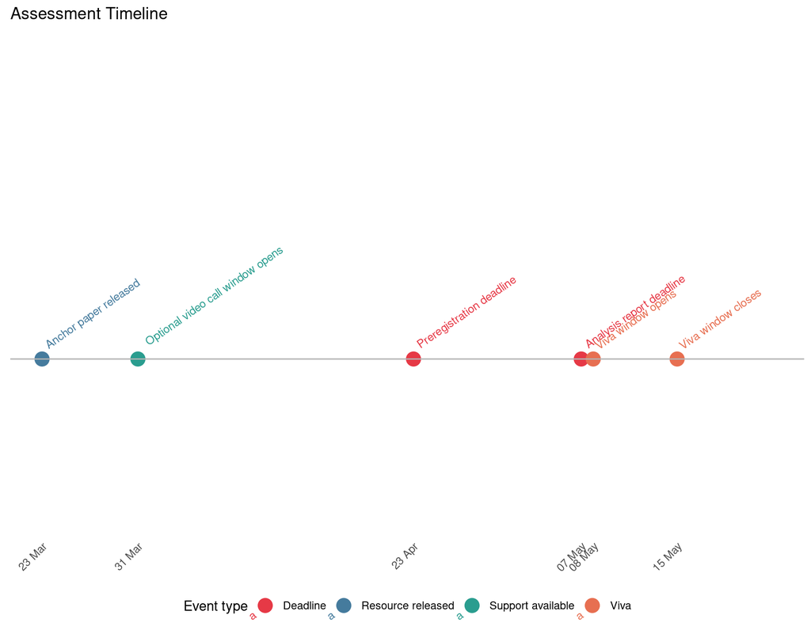

## The Optional Video Call

You may book a single 20-minute call with your supervisor before the preregistration deadline.

- Not assessed — nothing said affects your mark
- Purpose: to help you resolve genuine uncertainties before you commit
- Available during weeks three and four — book via the course portal

**Come with a specific question**

A call without a clear purpose is unlikely to be useful. Your supervisor will not tell you whether your preregistration is correct. They will help you think through a problem you have identified yourself.

**Note**

You are entitled to one call. Additional calls will not be scheduled.

## Key Takeaways

**1. The viva is the assessment — the written work is the evidence base**

**2. The preregistration is a record of your thinking, not a contract**

Deviation is expected. Unexplained deviation is penalised.

**3. AI has a clear boundary in this assessment**

Coding: permitted. Literature finding: permitted with documentation. DAG, hypotheses, model specification: will be exposed in the viva.

**4. The commit log is live assessment material**

Two-field format. Decisions and reasons. Written as if someone who does not know your analysis will read it — because they will.

**5. Intellectual honesty in the viva scores better than false confidence**

Saying “I am not certain but I think…” with reasoning is better than a confident wrong answer.

# Questions

## Back to the Board

We wrote down your uncertainties at the start of the session.

Let us address any that have not been covered.

If any remain genuinely unresolved, I will follow up in writing via the course portal within 48 hours.

## Before You Leave

What is the **first concrete thing** you are going to do this week to start the preregistration?

Take two or three answers from the room.

## Common Questions

**Q: Can I change my hypothesis after seeing the data?**

You can — but you must flag it as a deviation in your report and explain why. The viva will ask you to discuss it.

**Q: What if my analysis does not reproduce on the marker’s machine?**

Note the problem explicitly in your document with an explanation. An acknowledged reproducibility issue is treated more favourably than a silent failure.

**Q: What if I cannot find enough papers for the effect size extraction?**

Note this in your preregistration. Fewer than three papers is itself informative about the state of the literature. A sensitivity analysis across plausible effect sizes is the appropriate response.

**Q: What if my results are null?**

A null result reported honestly with appropriate context is worth more than an overinterpreted significant result. The viva rewards honest engagement with what you found, not a particular outcome.